# Homework 2:

Alessandro Quattrociocchi - Juan Mata Narajo

## Introduction

In this homework, are reported some results regarding the implementation of the EM algorithm for the fit of the Bart distribution. This particular distribution is a mixture of 6 six Gaussian.

$$\begin{align*}
p(x) = \frac{1}{2} \phi(x|0,1) + \frac{1}{10}\sum_{j = 0}^{4} \phi\bigg(x| \frac{j}{2}-1, \frac{1}{10}\bigg)
\end{align*}$$

$\phi (x| \mu, \sigma)$ is the Normal density of mean $\mu$ and standard deviation of $\sigma$.

This list summarizes what has been done during the homework assignment and also the way in which the results will be presented:

- Extension of the EM-fit for a generic mixture Gaussian and general k.
- Prove of the asymptotic and non-asymptotic regime with two different sample sizes.
- Implementation of eight different methods to select the number of components k.
- Comments and explanations of the provided methods and final consideration.

For each part, the functions that have been implemented are shown: first the role of the individual function and some theoretical aspects that have been considered in the algorithms. More comments on the nature of the code have been added directly inside the code.

We first begin by showing a random Bart sample where we can see the final MoG (curve in red) and all of the individual Gaussians that compose it (in light gray) for two different sample sizes

```r
bart_distribution_values = bart_distribution(2000)
```

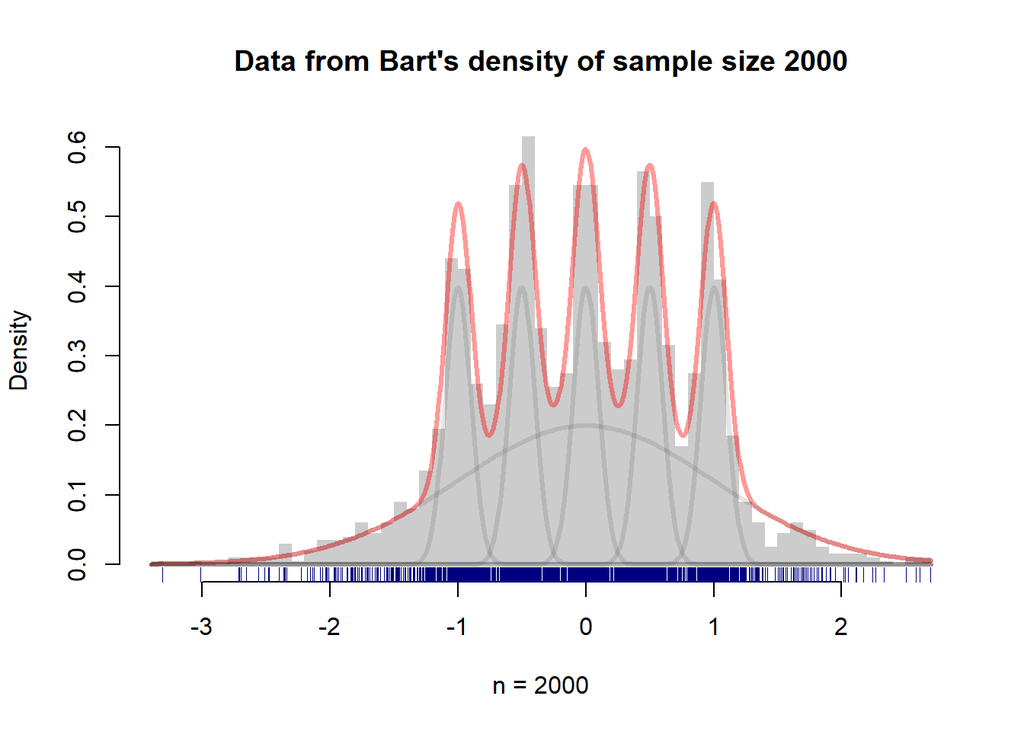

```r
bart_distribution_values = bart_distribution(20)
```

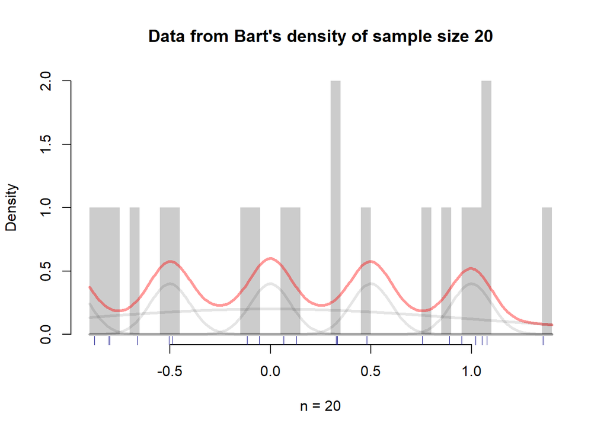

### Question 1 ~ Extend EM-fit for generic Mixture of Gaussians

Given the EM code provided during lectures we have extended it for a general number of k (the number of hidden gaussians). The main approach used for this was the use of the *sapply* function which evaluates a function over an array in a stepwise manner.

The output of this EM-fit function shows the parameter evolution over the provided sample distribution. The optimal parameters (from now on theta MLE parameters) are also returned.

```r
handmade.em_extended <- function(y, p, mu, sigma, n_iter, plot_flag = F,
                                 plot_final = F)
{
  # y:     Data to fit MoG using EM
  # p:     Initial weight guess (to be provided as a vector that sums up to 1)
  # mu:    Initial mu (Gaussian mean) parameters of all the Gaussian models (to
  #        be provided as a vector)
  # sigma: Initial sigma parameters (Gaussian standard error) parameters of all
  #        the Gaussian models (to be provided as a vector)
  # The number of hidden gaussians will be inferred by the length of the initial
  # parameter guesses

  k = length(p)
  cols     <- c("#FF00004D", "#00FF004D", "#7FC97F", "#BEAED4", "#FDC086",
                "#FFFF99", "#386CB0",
                "#F0027F", "#BF5B17", "#666666", "#1B9E77", "#D95F02",
                "#7570B3", "#E7298A", "#66A61E", "#E6AB02", "#A6761D",
                "#666666", "#A6CEE3", "#1F78B4", "#B2DF8A")

  # Estimate the log-likelihood (length of y)
  like     <- rowSums(sapply(1:k,
                             function (i) p[i]*dnorm(y,
                                                     mean = mu[i],
                                                     sd = sigma[i])))
  deviance <- -2*sum(log(like))
  res      <- matrix(NA,n_iter + 1, 2 + 3*k)
  res[1,]  <- c(0, p, mu, sigma, deviance)
  for (iter in 1:n_iter) {

    # E step --> Get the responsibilities. For more k values we would have to
    # compute d1, d2, d3, ..., etc. and then normalize them all
    # Compute responsibilities matrix, not yet normalized (each column is
    # associated with one class)
    temp_responsibilities <- sapply(1:k,
                                    function (i) p[i]*dnorm(y,
                                                            mean = mu[i],
                                                            sd = sigma[i]))

    # Normalize responsibilities
    responsibilities <- temp_responsibilities /  rowSums(temp_responsibilities)

    # M step
    for (i in 1:k) {

      p[i]     <- mean(responsibilities[,i])
      mu[i]    <- sum(responsibilities[,i]*y)/sum(responsibilities[,i])
      sigma[i] <- sqrt( sum(responsibilities[,i]*(y^2))/sum(responsibilities[,i]) - (mu[i])^2 )

    }

    # -2 x log-likelihood (a.k.a. deviance)
    like_temp     <- sapply(1:k,
                                    function (i) p[i]*dnorm(y,
                                                            mean = mu[i],
                                                            sd = sigma[i]))
    like <- rowSums(like_temp)
    deviance <- -2*sum( log(like) )

    # Save results to matrix
    res[iter+1,] <- c(iter, p, mu, sigma, deviance)

    # Plot
    if (plot_flag){
      hist(y, prob = T, breaks = 30, col = gray(.8), border = NA,
           main = "", xlab = paste("EM Iteration: ", iter, "/", n_iter,
                                   sep = ""))
      curve(rowSums(sapply(1:k,
                           function (i) p[i]*dnorm(x,
                                                   mean = mu[i],
                                                   sd = sigma[i]))),
            lwd = 4, col = rgb(1,0,0,.5), add = TRUE)
      for (i in 1:k) {

        curve(p[i]*dnorm(x, mean = mu[i], sd = sigma[i]),
              col = rgb(0, 0, 0, 0.4), lwd = 2,
              n = 500, add = TRUE)

      }
      points(jitter(y), rep(0,length(y)),
             pch = 19, cex = .8,
             col = cols[max.col(like_temp)])
      if (n_iter < 30) {
      Sys.sleep(1.5)}
    }
  }

  if (plot_final){
    hist(y, prob = T, breaks = 30, col = gray(.8), border = NA,
         main = k, xlab = paste("EM Iteration: ", iter, "/", n_iter,
                                 sep = ""))
    curve(rowSums(sapply(1:k,
                         function (i) p[i]*dnorm(x,
                                                 mean = mu[i],
                                                 sd = sigma[i]))),
          lwd = 4, col = rgb(1,0,0,.5), add = TRUE)
    for (i in 1:k) {

      curve(p[i]*dnorm(x, mean = mu[i], sd = sigma[i]),
            col = rgb(0, 0, 0, 0.4), lwd = 2,
            n = 500, add = TRUE)

    }
    points(jitter(y), rep(0,length(y)),
           pch = 19, cex = .8,
           col = cols[max.col(like_temp)])
    if (n_iter < 30) {
      Sys.sleep(1.5)}
  }

  res <- data.frame(res)
  names(res) <- c("iteration",
                  sprintf("p%d", 1:k),
                  sprintf("mu%d", 1:k),
                  sprintf("sigma%d", 1:k),
                  "deviance")
  out <- list(parameters = c(p = p, mu = mu, sigma = sigma),
              deviance = deviance, res = res)
  return(out)
}
```

Next we will show how the code performs (over a small number of iterations) to show the trend of our parameters in search of the optimal ones. We will start out with the already known Bart distribution parameters (the ones we use to generate the samples) as initial guesses for this simple example.

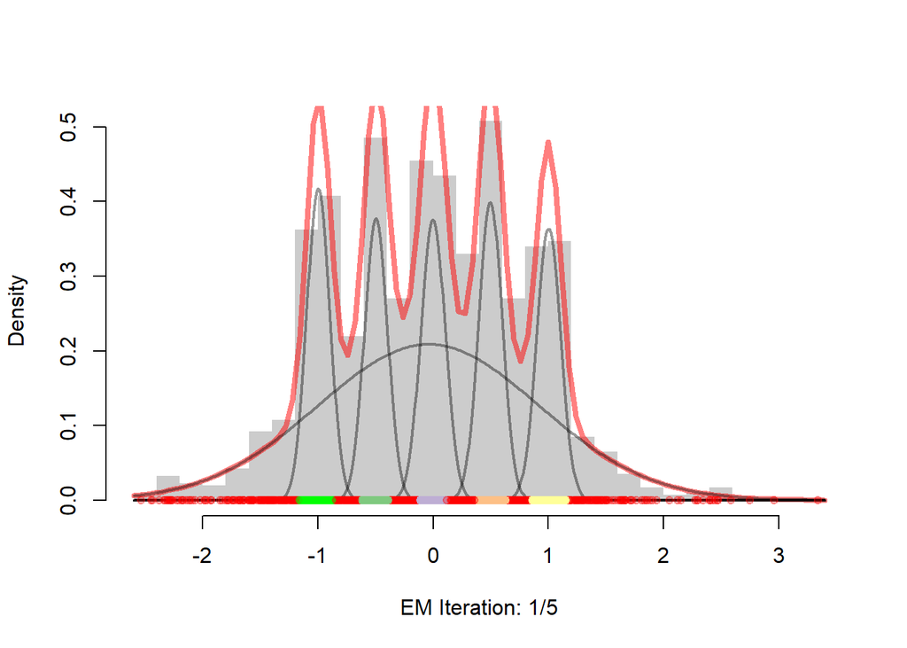

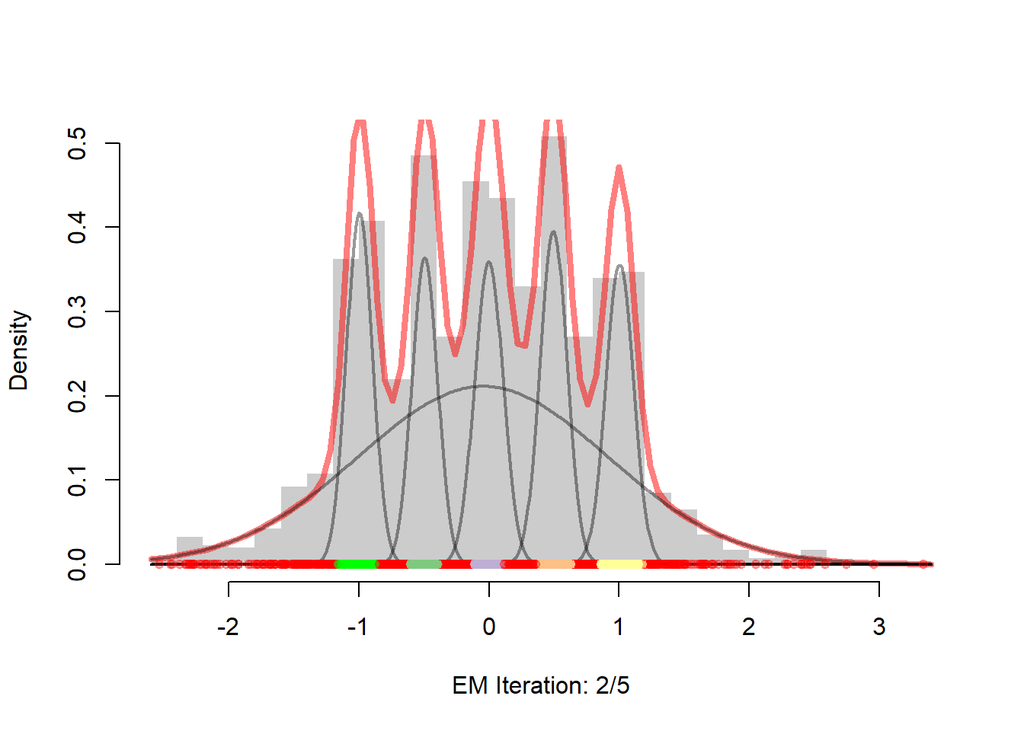

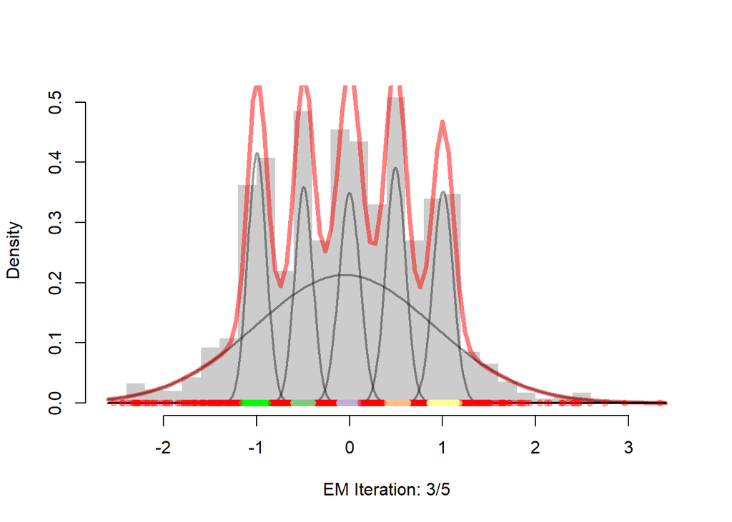

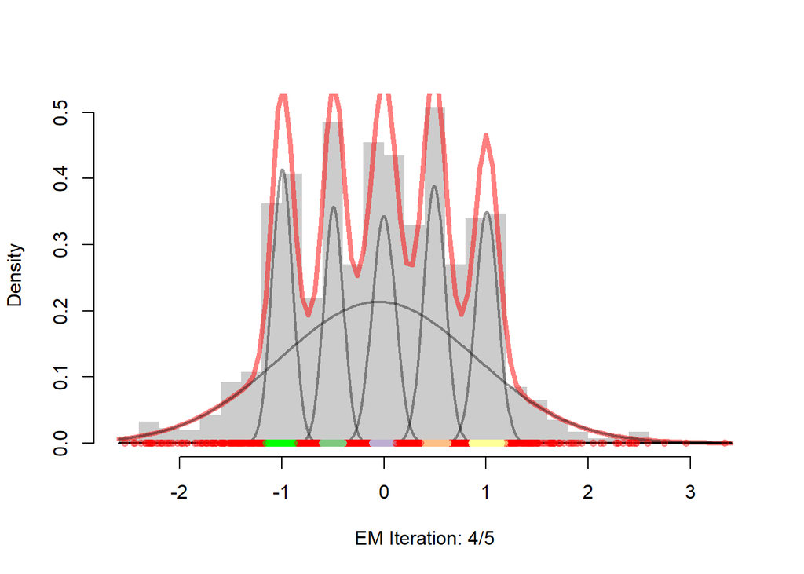

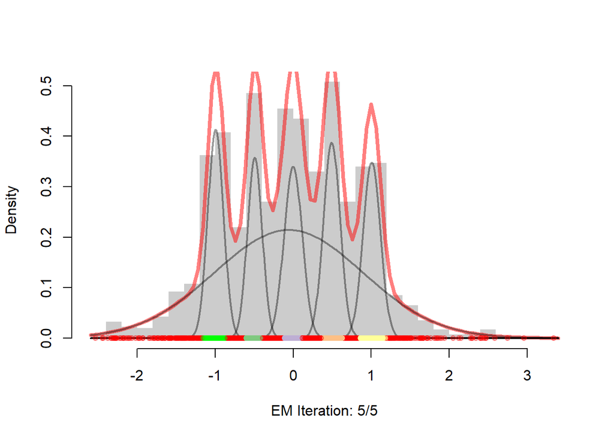

```r
hem_fit_extended <- handmade.em_extended(bart_distribution(2000, plot_flag=F),
                                         p = c(0.5, .1, .1, .1, .1, .1),
                                         mu = c(0, -1, -.5, 0, .5, 1),
                                         sigma = c(1, .1, .1, .1, .1, .1),
                                         n_iter = 5, plot_flag = T)
```

# Question 2 ~ Non-Asymptotic and Asymptotic regime.

Given two different sample size, we will prove two different behaviors of our EM-fit over 1000 simulations. For the first sample of size $n_1$ we will show a non-asymptotic behavior of its $\theta_{MLE}$ parameters, while for the second sample of size $n_2$ ($n_1$ < $n_2$) we will be able to show that the single $\theta_{MLE}$ parameters show an asymptotic behavior.

In other words we can show that for 1000 simulated **$\theta_{MLE}$** vectors, if n is sufficiently large, the following must hold:

$$\begin{align}
\frac{\hat{\theta_r} - \theta_r}{\hat{se_r}}\xrightarrow{d}N_1(0, 1)
\end{align}$$

where $r$ represents the $r^{th}$ parameter of the estimated and true $\theta$. The true $\boldsymbol{\theta}$ estimate of our Bart distribution are known to us (i.e. we are in a well specified model scenario).

We will show this without standardizing our $\hat{\theta_r}$ but the same principle is applicable and proves this trend.

```r
probe_asymptotic_regime(n1 = 50, n2 = 3000, simulations = 1000,
                        check_parameter = 'p1', true_value = 0.5)
```

[figure not shown]

```r
probe_asymptotic_regime(n1 = 50, n2 = 3000, simulations = 1000,
                        check_parameter = 'mu2', true_value = -1)
```

[figure not shown]

```r
probe_asymptotic_regime(n1 = 50, n2 = 3000, simulations = 1000,
                        check_parameter = 'sigma5', true_value = 0.1)
```

[figure not shown]

# Question 3 & 4 ~ Model Selection

Before looking into the individual model selection techniques we will first give an overview of the procedures we have used to estimate each of these metrics and therefore choose the best k from our **randomly** sampled Bart distribution data.

1. Despite being in a well specified model scenario and exactly knowing the parameters used to generate the true Bart distribution, the data we are using to fit is random. In order to overcomes this issue and get the best possible estimate parameters (and given that we are following a frequentist approach) we will repeat the sampling scheme M times to get a better grasp of the true parameters ($\boldsymbol\theta_{MLE}$).
2. Therefore, for each of the M simulations we will estimate $\boldsymbol\theta_{MLE}$ given a specific k value. For each of these simulations we will estimate a different model selection metric value (e.g. for a fixed k, fixed sample size, if M=100, we will produce 100 AIC/BIC/CV values) and we take the average over all of these metrics (excluding cases in which EM-fit did not converge).
3. The best model (i.e. best k value) is chosen by maximizing/minimizing the model selection metric among all k values.

Previous bullet point number 2 requires the estimation of how good/bad a given model is when trying to estimate the real data distribution. For this purpose we will investigate and quantify two different loss functions (Kullback-divergence and the Wasserstein distance) over two different quantities:

1. **Kullback-divergence**: Comparing the estimated likelihood of our model (k) with the $\boldsymbol\theta_{MLE}$ parameters over the randomly sampled Bart distribution data and the “true” density function.

$$\begin{align}
L(f_X, \hat{f_j}) = \int_{\chi}f_X(x)log\bigg(\frac{f_X(x)}{\hat{f_j(x)}}\bigg)
\end{align}$$

2. **Wasserstein Distance**: Comparing the quantile function of a k component MoG (evaluate over the $\boldsymbol\theta_{MLE}$ parameters and some splitted test data) and true quantile function of the distribution (since this is not known we approximate it using the ECDF of the test data)

$$\begin{align}
\boldsymbol{W_{k}} = \int_{0}^{1}|F_k^{-1}(z|\boldsymbol\theta) - F_X^{-1}(z)|dz
\end{align}$$

From the previous loss functions the unknown quantity is the density distribution we are comparing our results against. In the case of the Wasserstein we have already mentioned how to estimate this quantity, however for the Kullback Divergence we still need to specify how to estimate it (there are different ways of doing this depending on the model selection process):

$$\begin{align}
R_j = E_{f_X}(log(\hat{f_j(X)}))
\end{align}$$

$f_X$ is unknown to us, so it will be estimated in two different manners:

1. AIC/BIC: Using a plug-in estimator evaluated over the same data over which the $\boldsymbol\theta_{MLE}$ was estimated:

$$\begin{align}
\hat{R_j} = \frac{1}{n}\sum_{i=1}^{n}(log(\hat{f_j}(X_i|\theta_{MLE})))
\end{align}$$

BIC and AIC will try to compensate for this bias by penalizing overfitting (model complexity)

2. Cross Validation/Sample Splitting: Evaluating the performance of our model over some test data

$$\begin{align}
\hat{R_j} = \frac{1}{n}\sum_{i=1}^{n}(log(\hat{f_j}(X_i^{*}|\theta_{MLE})))
\end{align}$$

Given that most part of the code for all model selection techniques are similar, we will only show one of them as an example. All of the other model selection codes have the same structure and can be found in the *.Rmd*.

```r
aic_score_given_k <- function(k, n, M, MLE_iterations,
                              true_p = c(0.5, .1, .1, .1, .1, .1),
                              true_mu = c(0, -1, -.5, 0, .5, 1),
                              true_sigma = c(1, .1, .1, .1, .1, .1)) {
  # k: number of hidden gaussians
  # n: sample size from which we will learn
  # M: number of iterations (we will resample M times with sample size of n)
  # MLE_iterations: Number of iterations used to find optimal theta_MLE parameters

  guesses = initial_guess(k, true_p = true_p, true_mu = true_mu,
                          true_sigma = true_sigma)
  p = guesses$p
  mu = guesses$mu
  sigma = guesses$sigma
  aic_score = rep(NA, M)

  for (simulation in (1:M)) {
    # Generate data based on the first simulation step
    random_data = bart_distribution(n, F)


    # Fit model to obtain best parameter values using EM fit
    theta_MLE = handmade.em_extended(random_data, p=p, mu=mu, sigma=sigma,
                                     n_iter=MLE_iterations)

    # Get p, mu and sigma from the previous  fit
    p_MLE = as.vector(theta_MLE$parameters[(1:k)])
    mu_MLE = as.vector(theta_MLE$parameters[((k+1):(2*k))])
    sigma_MLE = as.vector(theta_MLE$parameters[((2*k+1):(3*k))])

    # Compute the likelihood that our test data (test_sample) really comes from the
    # model we have estimated with the theta_MLE
    f_j_hat = func_bart_density(random_data, p = p_MLE, mu = mu_MLE,
                                sigma = sigma_MLE)
    d_j = 3*k-1
    aic_score[simulation] <- (sum(log(f_j_hat)) - 2*d_j)

  }
  # Average over all the simulations we have performed
  #return(mean(na.omit(aic_score)))
  k = mean(na.omit(aic_score))
  return(k)
}
```

```r
aic_score <- function(k_max, n, M, MLE_iterations,
                      plot_flag = T) {
  # This function will loop over all k values from 1 to k_max computing the
  # score for each kth model. The optimal kth model will be picked upon these
  # results

  final_scores = rep(NA, k_max)
  names(final_scores) = sprintf("k%d", 1:k_max)

  for (k in (1:k_max)) {
    print(k)

    final_scores[k] <- aic_score_given_k(k=k, n=n, M=M,
                                         MLE_iterations = MLE_iterations
    )
    print('=====================')
  }

  if (plot_flag) {

    plot((1:k_max), final_scores, type = "b", pch = 19,
         main = paste0("AIC estimation with sample size ", n, sep=''),
         col = "red", xlab = "Number of Gaussians (k)", ylab = "AIC value")

  }

  return(final_scores)
}
```

### AIC Method

The AIC metric is computed using the following equation (no data split is used for this method):

$$\begin{align}
AIC_k = \sum_{i=1}^{n}(log(\hat{f_j}(X_i|\theta_{MLE}))) - 2 \cdot d_{k}
\end{align}$$

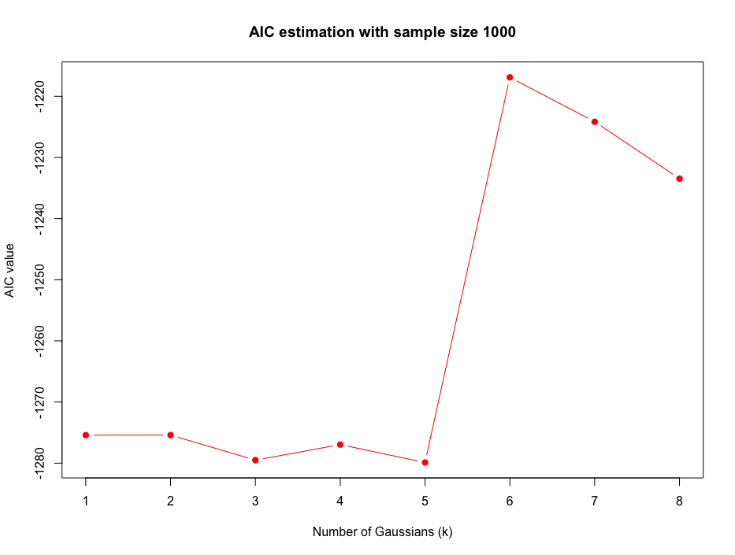

From the previous plot, and since we want to maximize our AIC values (maximizing AIC means maximizing the likelihood based on how we define the AIC metric) we can confirm that the best model would be the one with k=6 (the model which we already know is the true MoG). In particular, in the AIC criterion, we have to consider the difference value between two values of k. As the plot shows we have a significant difference from k = 5 to k = 6 (the true value of k of Bart distribution). In general, the AIC criterion returns an optimistic evaluation of the model, focusing on the most adequately k to describe model behaviour appropriately.

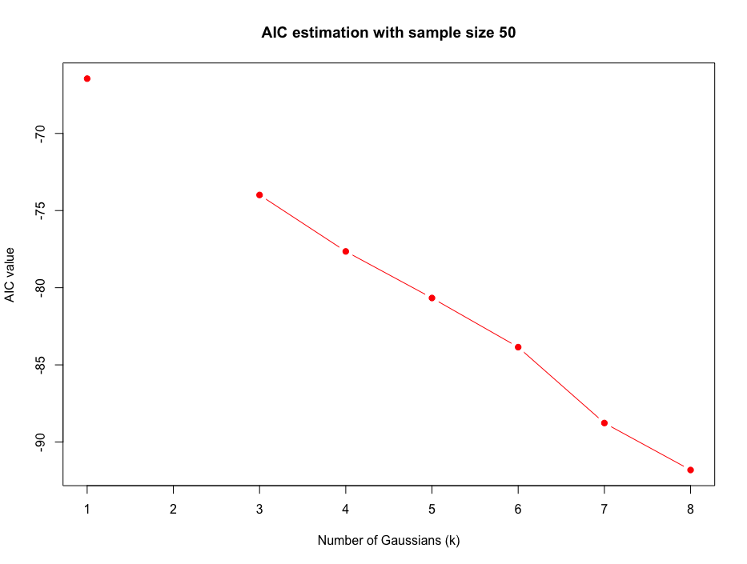

For a smaller sample size, we can see that for some values of k we have no convergence and the estimate of AIC is not significant.

### BIC Method

The BIC metric is computed using the following equation (no data split is used for this method):

$$\begin{align}
BIC_k = \sum_{i=1}^{n}(log(\hat{f_j}(X_i|\theta_{MLE}))) - \frac{log(n)}{n} \cdot d_{k}
\end{align}$$

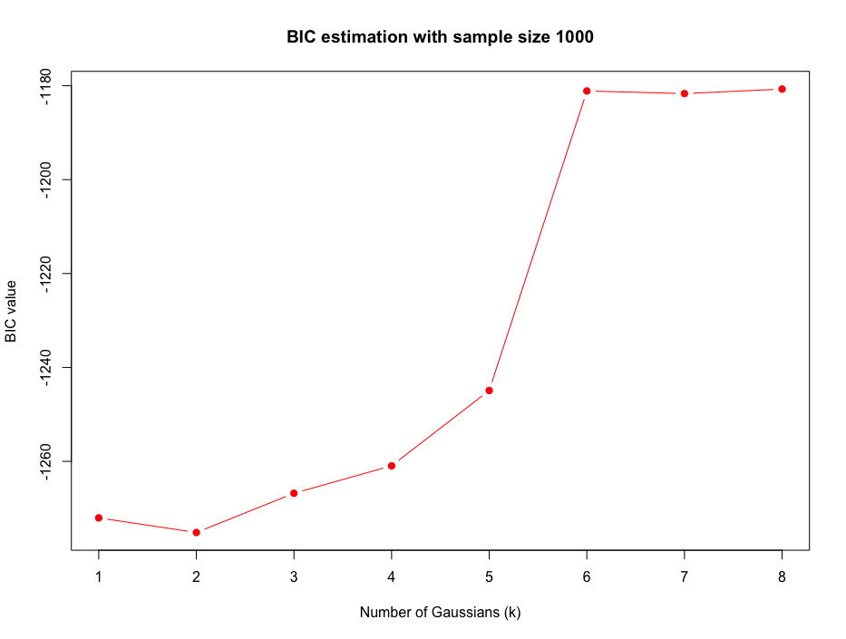

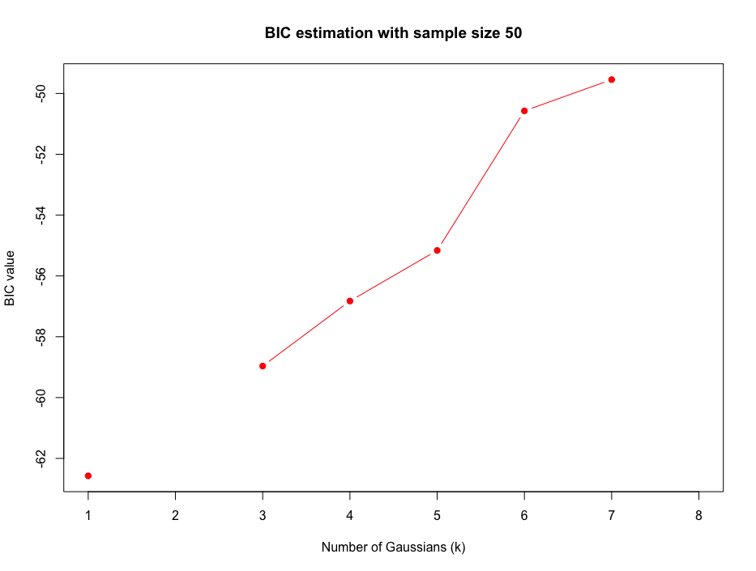

As with the AIC estimation, we can see that the estimation for small sample size is not significant, as it is very distant from that for larger sample sizes.

### Sample Splitting Method

One of the main flaws of the AIC and BIC methods is that they evaluate the optimal model performance over the same data used to train the model. This can be avoided by evaluating the model over some unseen (test data).

Evaluating this model selection technique over different train/test split proportions we get the following results:

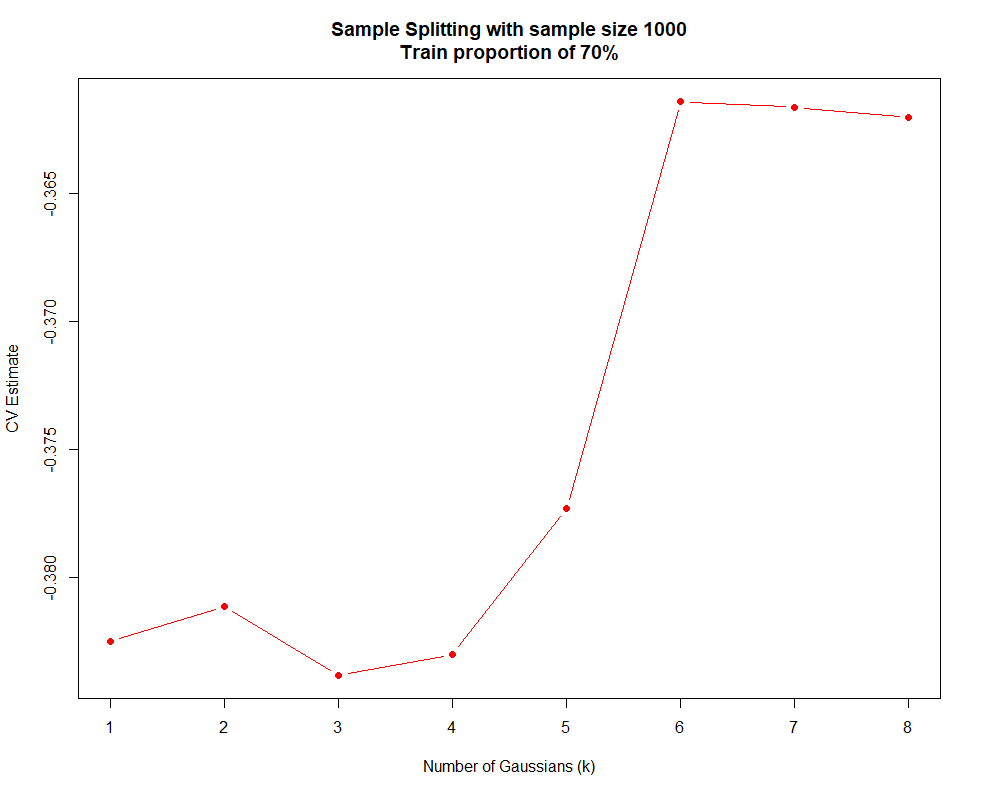

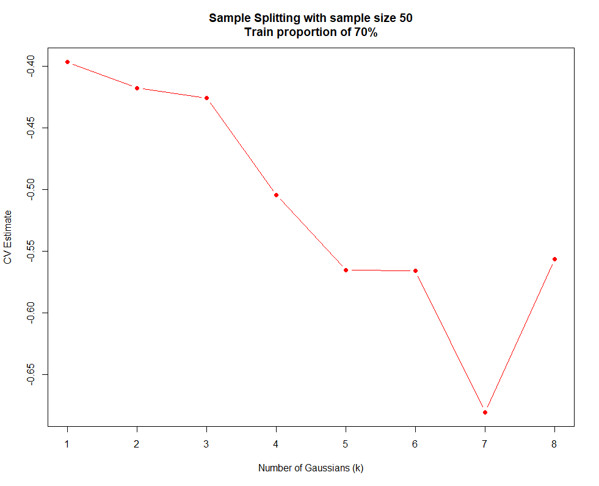

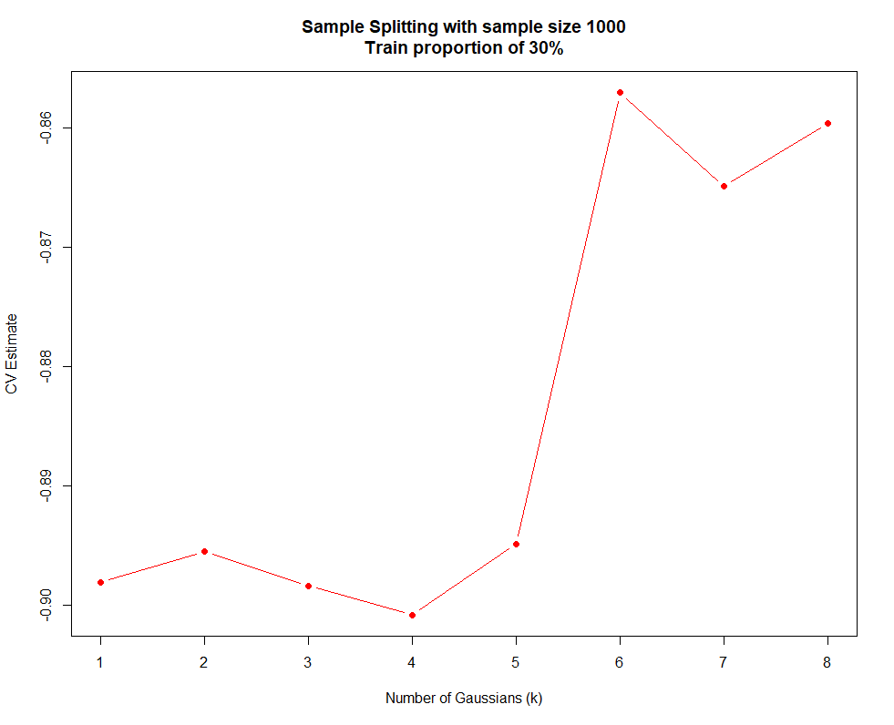

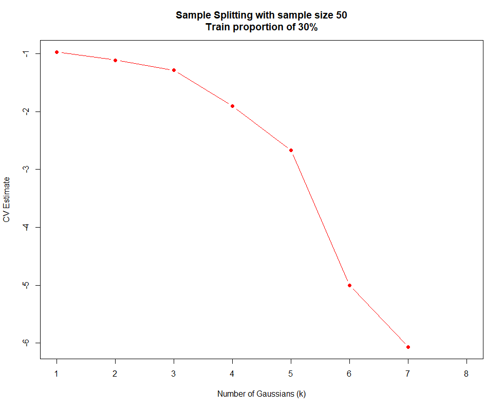

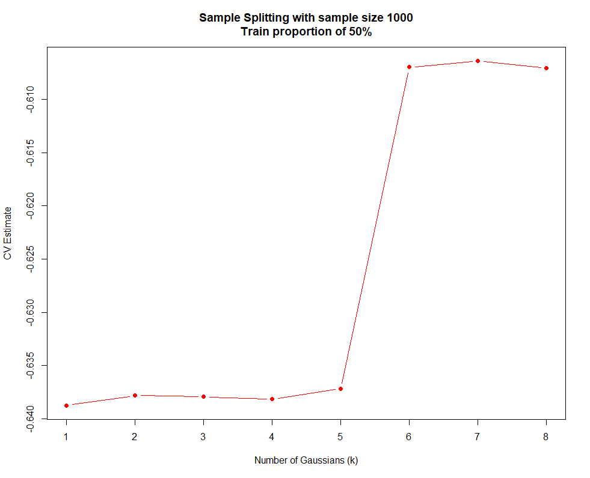

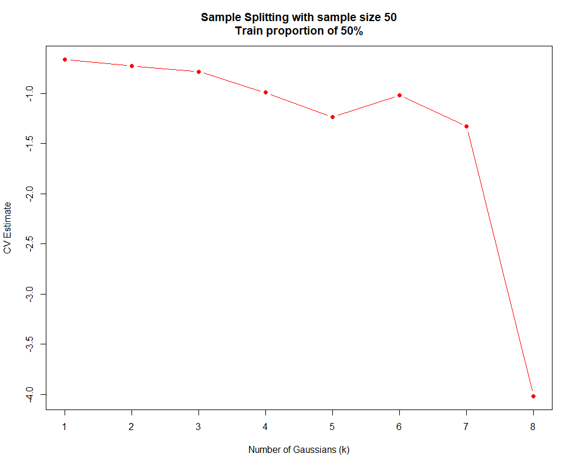

In general lines we can conclude the following from the previous figures:

1. As we expected, performance with small sample size are insignificant, regardless all the simulations we have done. This is another consequence of the fact that with small sample size the EM-fit does not converge to the true parameters. Additionally, if besides having a small sample size we also split this small sample into test and train, the train and test data can end up being any kind of strange distribution.
2. We can also see that in general the model has been able to properly predict that k=6 is the true value of our MoG distribution, although closely followed by higher k values.
3. Another final observation is that the higher the proportion of the train data used for the EM-fit, the higher the CV Estimate (risk) value is, and therefore the smaller the Kullback Leibler divergence is.

### K-fold Cross Validation Approach

Similarly to the sampling split technique, the cross validation also learns the $\boldsymbol\theta_{MLE}$ parameters from a specific proportion of the total train data set, and leaves the remaining proportion of data for the performance evaluation. The main difference is that the Cross Validation Approach goes one step further and uses a set of K-folds for this purpose. This means that it splits the data in K-fold chunks (5 and 10 in our case) making each proportion of the including every observation of the data once in the test sample. The CV metric is then averaged over the result of each K-fold, resulting in a much more robust method.

The results of this approach can be seen in the following figures:

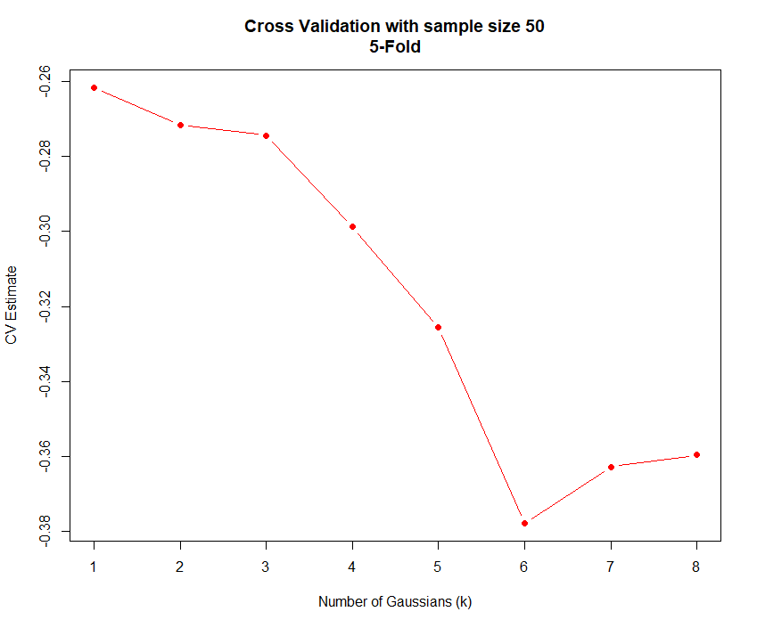

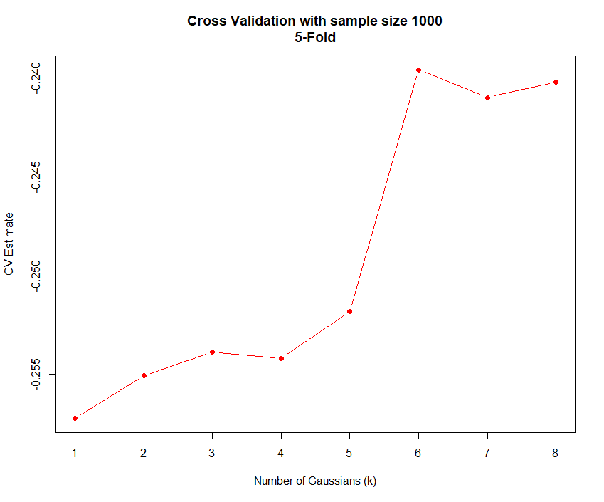

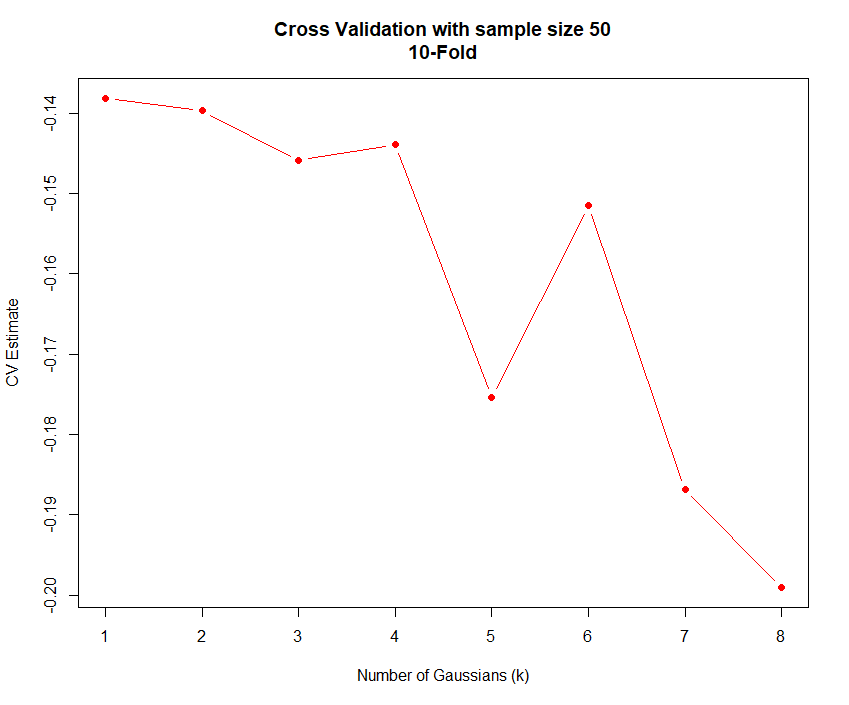

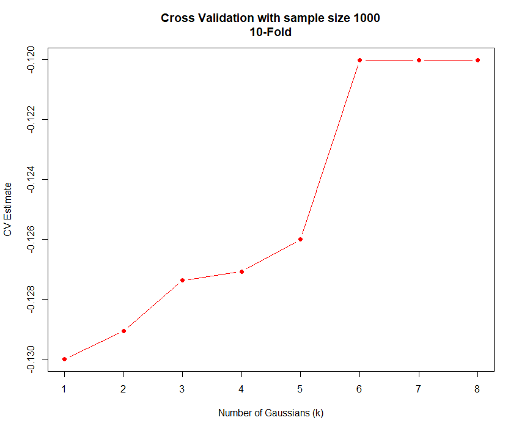

From these we can also highlight the following observations:

1. As already observed in the previous methods, the performance of our model selection does not provide good results for small sample sizes.
2. The true k value is the value that has been choosen to be the best by this model selection (maximizing the CV estimate), however it came as quite a surprise that values with higher k values (k=7, 8) also performed so well over the test data.

### Wasserstein Distance

Finally we will also be looking into the Wasserstein distance which mainly focuses on the comparison between the quantile functions of the estimate CDF and the quantile function of the “true” CDF function, which will be estimated as the ECDF (given that the true CDF is unknown).

Simiarly to the Sample Split approach, this distance will also be evaluated over the test data (50% of the total sampled data) while the other 50% will be used to estimate the $\boldsymbol{\theta}_{MLE}$.

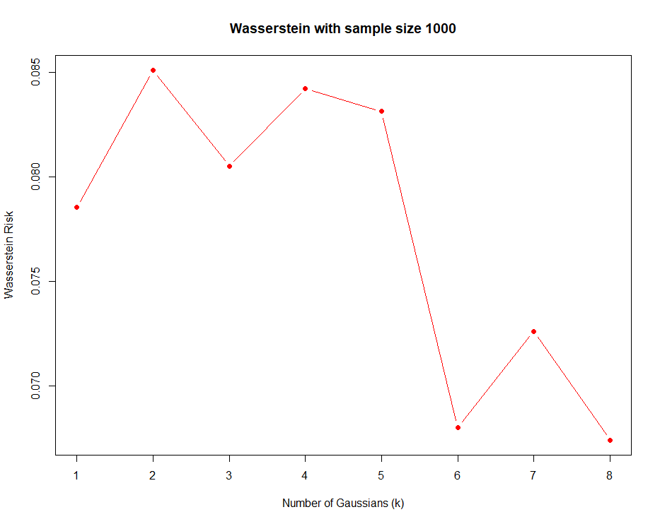

### Final Numerical Results

Finally, and in order to evaluate the performance of all the model selection techniques shown before we have estimated two confidence intervals, namely Heoffding and Chebyshev. These confidence intervals are built around the best model selection estimate values. In other words we will be estimating the following probability for a fixed alpha value (0.05):

$$\begin{align}
P(\underset{k}{\operatorname{max}}|\hat{R_k}-R_k| < \epsilon(\alpha)) \geqslant 1 -\alpha
\end{align}$$

where epsilon will be different for both Chebyshev and Hoeffding.

The main reason for which we can build these intervals is nothing other than due to the fact that the $R_k$ values we have estimated are simple expected values.

Despite the fact that we can apply these confidence intervals in order to evaluate how well our model selection techniques estimate the true risk around our model choice, we have not been able to properly estimate the following parameters (mainly used for the Hoeffding confidence intervals):

- **Model Cardinality**: Given that we are not only choosing between kmax models, but over an infinite set of continuous model parameters for our MoG, we have not been able to estimate this quantity properly.
- **Upper and Lower bounds**: It can be shown that the log likelihood is a bounded value, which can be used by Hoeffding to better estimate the confidence intervals. We were not able to properly estimate these upper and lower bounds and have therefore chosen to pick to reasonably large upper and lower bounds of this quantity (-1000 and 1000)

The results for all model selection techniques are shown in the table below (we are only computing these intervals over the results obtained for large sample sizes given that results with small sample size were so inconsistent).

[output not shown]